# Capítulo 3 - Dados do Problema

## Conjunto de dados (treino)

```python
df_training.head() #.iloc[:,:-1]
```

|  | id | era | data_type | feature_intelligence1 | feature_intelligence2 | feature_intelligence3 | feature_intelligence4 | feature_intelligence5 | feature_intelligence6 | feature_intelligence7 | ... | feature_wisdom38 | feature_wisdom39 | feature_wisdom40 | feature_wisdom41 | feature_wisdom42 | feature_wisdom43 | feature_wisdom44 | feature_wisdom45 | feature_wisdom46 | target_kazutsugi |
| --- | --- | --- | --- | --- | --- | --- | --- | --- | --- | --- | --- | --- | --- | --- | --- | --- | --- | --- | --- | --- | --- |
| 0 | n000315175b67977 | 1 | train | 0.00 | 0.50 | 0.25 | 0.00 | 0.5 | 0.25 | 0.25 | ... | 1.00 | 1.00 | 0.75 | 0.50 | 0.75 | 0.50 | 1.00 | 0.50 | 0.75 | 0.75 |
| 1 | n0014af834a96cdd | 1 | train | 0.00 | 0.00 | 0.00 | 0.25 | 0.5 | 0.00 | 0.00 | ... | 1.00 | 1.00 | 0.00 | 0.00 | 0.75 | 0.25 | 0.00 | 0.25 | 1.00 | 0.25 |
| 2 | n001c93979ac41d4 | 1 | train | 0.25 | 0.50 | 0.25 | 0.25 | 1.0 | 0.75 | 0.75 | ... | 0.25 | 0.50 | 0.00 | 0.00 | 0.50 | 1.00 | 0.00 | 0.25 | 0.75 | 0.00 |
| 3 | n0034e4143f22a13 | 1 | train | 1.00 | 0.00 | 0.00 | 0.50 | 0.5 | 0.25 | 0.25 | ... | 1.00 | 1.00 | 0.75 | 0.75 | 1.00 | 1.00 | 0.75 | 1.00 | 1.00 | 0.00 |
| 4 | n00679d1a636062f | 1 | train | 0.25 | 0.25 | 0.25 | 0.25 | 0.0 | 0.25 | 0.50 | ... | 0.75 | 0.75 | 0.25 | 0.50 | 0.75 | 0.00 | 0.50 | 0.25 | 0.75 | 0.75 |

5 rows × 314 columns

```python
for group, f_list in feature_groups.items():
    print(f_list[-1])
```

```
feature_intelligence12
feature_wisdom46
feature_charisma86
feature_dexterity14
feature_strength38
feature_constitution114
```

### Algumas features dentro do mesmo grupo são altamente correlacionadas

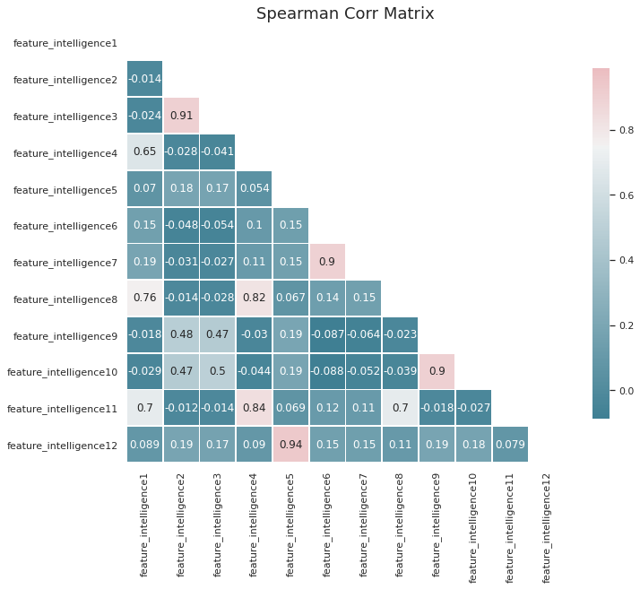

```python
visualize.plot_corr_matrix(df_training[feature_intelligence])
```

```python
print()
print()
print()
print()
```

### Essa correlação muda com o passar das eras

Comparamos a correlação de **pearson** nas primeira metade (eras 1-60), com a segunda metade (era 61-120)

```python
tdf = pd.DataFrame({
    "corr1": corr1,
    "corr2": corr2,
})
tdf["corr_diff"] = tdf.corr2 - tdf.corr1
tdf.sort_values(by="corr_diff").head().style.set_properties(**{'font-size': '20 pt'})
```

|  |  | corr1 | corr2 | corr_diff |
| --- | --- | --- | --- | --- |
| feature_intelligence11 | feature_intelligence9 | 0.0914 | -0.1289 | -0.2202 |
| feature_intelligence10 | feature_intelligence11 | 0.0750 | -0.1305 | -0.2055 |
|  | feature_intelligence4 | 0.0548 | -0.1442 | -0.1990 |
| feature_intelligence4 | feature_intelligence9 | 0.0676 | -0.1296 | -0.1972 |
| feature_intelligence10 | feature_intelligence8 | 0.0549 | -0.1354 | -0.1903 |

#### O relacionamento entre as variáveis é inconsistente

## Sobre o target

- Proporção dos valores do target é similar ao *Numerai Signals*
- A Quantidade de ações monitorada dentro das 120 eras (mensais) é variável.

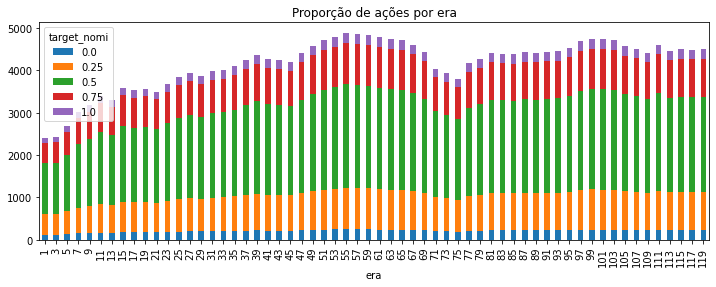

```python
targets = df_training.loc[:, ['era', target]]
pivot_target = targets.groupby(['era', target]).apply(lambda x: len(x)).reset_index(1).pivot(columns=target,values=0)
pivot_target.iloc[::2].plot(kind='bar', stacked=True, figsize=(12,4), title='Proporção de ações por era');
```

#### Lembrando toda era começa na sexta feira e precisamos prever o retorno de cada ação para o período subsequente

## Algumas features possuem correlação com o target

```python
pd.Series(feature_scores).sort_values(ascending=False)
```

```
feature_strength34     0.0123
feature_strength14     0.0115
feature_charisma37     0.0110
feature_charisma18     0.0108
feature_charisma76     0.0107
                        ...
feature_dexterity11   -0.0102
feature_charisma69    -0.0103
feature_dexterity4    -0.0110
feature_dexterity6    -0.0111
feature_dexterity7    -0.0115
Length: 310, dtype: float64
```

### Lembre-se que a relação sinal-ruído é extramamente baixa

### Como uma feature se comporta com relação ao target por era

Lembrete: Uma feature é um indicador financeiro

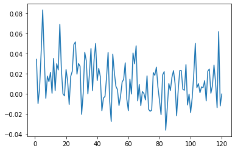

```python
# Single features do not work consistently though
by_era_correlation = pd.Series({
    era: np.corrcoef(tdf['target_kazutsugi'], tdf["feature_strength34"])[0,1]
    for era, tdf in df.groupby(eras)
})
by_era_correlation.plot();
```

#### Analisando a média movel de 12 eras (1 ano)

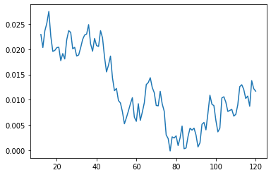

```python
# With a rolling 12 era average you can see some trends
by_era_correlation.rolling(12).mean().plot();
```

### Conclusão: Não podemos confiar demais em um grupo pequeno de features

## Modelo Baseline

[figure not shown]

- Equivale a um retorno de 8.5% a cada NMR investido (1NMR=25USD)

*Fonte: https://numer.ai/integration_test*

### Baseline

#### Modelo do Integration Test

```python
print("XGBRegressor(n_estimators=2000, learning_rate=0.01, max_depth=5, colsample_bytree=0.1)")
```

```
XGBRegressor(n_estimators=2000, learning_rate=0.01, max_depth=5, colsample_bytree=0.1)
```

### Lembrando que o target assume os valores {0, 0,25, 0,5, 0,75, 1}

#### Mas a avaliação é feita sobre a correlação de spearman

### Correlação de Spearman

$${\displaystyle r_{s}=\rho _{\operatorname {rg} _{X},\operatorname {rg} _{Y}}={\frac {\operatorname {cov} (\operatorname {rg} _{X},\operatorname {rg} _{Y})}{\sigma _{\operatorname {rg} _{X}}\sigma _{\operatorname {rg} _{Y}}}},}$$

[figure not shown]

#### entao estamos resolvendo um problema de ranqueamento

*Fonte: https://en.wikipedia.org/wiki/Spearman%27s_rank_correlation_coefficient*

### Tipos de Aprendizado Supervisionado

#### Classificação e Regressão

[figure not shown]

*Fonte: https://medium.com/opensanca/aprendizagem-de-maquina-supervisionada-ou-n%C3%A3o-supervisionada-7d01f78cd80a*

#### Ranqueamento

[figure not shown]

*Fonte: https://mlexplained.com/2019/05/27/learning-to-rank-explained-with-code/*

#### Podemos fazer das três formas

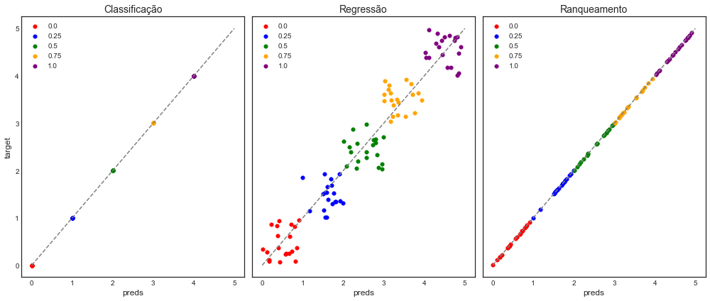

```python
#veja a lista completa com o comando acima
plt.style.use('seaborn-white')
import random
X1,X2 = [],[]
for i in range(5):
    X1 +=[[i,i,i/4] for _ in range(20)] #class
    X2 +=[[i+random.random(),i+random.random(),i/4] for _ in range(20)]


X1 = np.array(X1)
X2 = np.array(X2)

df_class = pd.DataFrame(dict(preds=X1[:,0], target=X1[:,1], label=X1[:,2])).groupby('label')
df_reg = pd.DataFrame(dict(preds=X2[:,0], target=X2[:,1], label=X2[:,2])).groupby('label')
df_rank = pd.DataFrame(dict(preds=X2[:,0], target=X2[:,0], label=X2[:,2])).groupby('label')

colors = {0:'red', .25:'blue', .5:'green', .75:'orange', 1:'purple'}
fig, (ax1, ax2, ax3) = plt.subplots(1, 3, sharey=True, tight_layout=True, figsize=(14,6))


title = ['Classificação', 'Regressão', 'Ranqueamento']
for ax, df in zip([ax1,ax2,ax3], [df_class, df_reg, df_rank]):
    dash = np.linspace(0,5,100)
    ax.plot(dash, dash, color='grey', linestyle='dashed')
    for key, group in df:
        group.plot(ax=ax, kind='scatter', x='preds', y='target', label=key, color=colors[key], s=30)

    ax.set_title(title.pop(0), fontsize=14)

plt.show()
```

### Qual dos três é o melhor?

###### Utilizamos 3 modelos top de linha e vamos comparar as implementações de classificação, regressão e ranqueamento.

- Xgboost (Microsoft)
- LightGBM (Microsoft)
- Catboost (Yandex)

#### Treinamos nas eras 1-60 e testamos nas eras 61-120

```python
results.sort_values(by=['outsample'], ascending=False).style.set_properties(**{'font-size': '30 pt'})
```

|  | outsample | insample | time_elapsed_GPU(s) | time_elapsed(s) |
| --- | --- | --- | --- | --- |
| LGBMRegressor | 0.0447 | 0.2677 | 23.8324 | 62.3275 |
| XGBRanker | 0.0442 | 0.2021 | 67.5707 | 469.0444 |
| XGBRegressor | 0.0440 | 0.2667 | 37.2466 | 445.6100 |
| LGBMClassifier | 0.0305 | 0.2070 | 137.1966 | 301.8254 |
| XGBClassifier | 0.0302 | 0.1648 | 232.9470 | 2172.2911 |
| CatBoostClassifier | 0.0271 | 0.0959 | 19.0138 | 1193.6433 |
| CatBoostRegressor | 0.0267 | 0.0949 | 9.2403 | 209.8839 |
| LGBMRanker | 0.0150 | 0.0647 | 6092.7200 | 16133.8554 |

### Avaliando Modelo de Classificação (LGBM Classifier)

```
              precision    recall  f1-score   support

           0       0.27      0.28      0.28     21352
           1       0.23      0.15      0.18     21363
           2       0.27      0.36      0.31     21474
           3       0.22      0.15      0.18     21362
           4       0.27      0.35      0.30     21344

    accuracy                           0.26    106895
   macro avg       0.25      0.26      0.25    106895
weighted avg       0.25      0.26      0.25    106895
```

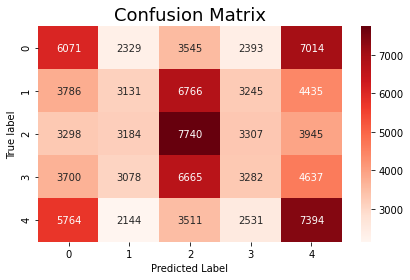

```python
evaluation.plot_confusion_matrix(lab_enc.fit_transform(df_validation[target]), preds/4)
```

### Os extremos e o meio das predições são muito correlacionados

```
array([[ 1.        , -0.81393351, -0.8942065 , -0.88654085,  0.78328667],
       [-0.81393351,  1.        ,  0.80874765,  0.72378902, -0.89877694],
       [-0.8942065 ,  0.80874765,  1.        ,  0.77462933, -0.90867348],
       [-0.88654085,  0.72378902,  0.77462933,  1.        , -0.80042416],
       [ 0.78328667, -0.89877694, -0.90867348, -0.80042416,  1.        ]])
```

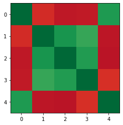

```python
corrs=np.corrcoef(model.predict_proba(df_validation[features]).T)
plt.imshow(corrs, vmin=-1, vmax=1, cmap="RdYlGn")
corrs
```

#### Modelos de classificação performam pior que os outros!

## Como treinar os modelos (validação)

[figure not shown]

*Fonte: https://scikit-learn.org/stable/modules/cross_validation.html*

```python
print()
print()
print()
print()
```

### Comparando Esquemas de Validação

#### 5-fold com e sem embaralhar

```python
for cv in crossvalidators:
    print(cv)
    print(np.mean(
            model_selection.cross_val_score(
            linear_model.LinearRegression(),
            df[features],
            df[target],
            cv=cv,
            n_jobs=1,
            groups=eras,
            scoring=metrics.make_scorer(correlation_score, greater_is_better=True)
        )))
    print()
```

```
KFold(n_splits=5, random_state=None, shuffle=False)
0.03658489467457003

KFold(n_splits=5, random_state=None, shuffle=True)
0.04360860798952288

GroupKFold(n_splits=5)
0.038069863851659315

TimeSeriesSplit(max_train_size=None, n_splits=5)
0.033943838232674675
```

### Como interpretar as eras

- Algumas eras são menos aplicáveis do que outras eras (regimes diferentes)

Vamos treinar um modelo em cada grupo de 10 eras e testar nas restantes

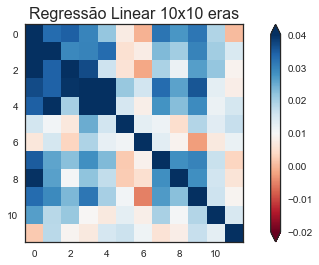

```python
import numpy as np
import matplotlib.pyplot as plt


fig, ax = plt.subplots(figsize=(10, 4), ncols=1)
ax.set_title('Regressão Linear 10x10 eras', fontsize=16)
pos_neg_clipped = ax.imshow(results_df, cmap='RdBu', vmin=-.02, vmax=.04)
cbar = fig.colorbar(pos_neg_clipped, ax=ax, extend='both')
cbar.minorticks_on()
plt.show()
```

- As eras do meio não parecem ser relevantes para as outras eras
- A performance do modelo parece decair ao longo do tempo

### Dataset de validação

- Usaremos o dataset de "validação"
- Eras 121-132 e 198-206 (dados do futuro)
- Dados referentes a rodadas anteriores já resolvidas (atualização semestral)

```python
df_validation.head()
```

|  | id | era | data_type | feature_intelligence1 | feature_intelligence2 | feature_intelligence3 | feature_intelligence4 | feature_intelligence5 | feature_intelligence6 | feature_intelligence7 | ... | feature_wisdom38 | feature_wisdom39 | feature_wisdom40 | feature_wisdom41 | feature_wisdom42 | feature_wisdom43 | feature_wisdom44 | feature_wisdom45 | feature_wisdom46 | target_kazutsugi |
| --- | --- | --- | --- | --- | --- | --- | --- | --- | --- | --- | --- | --- | --- | --- | --- | --- | --- | --- | --- | --- | --- |
| 0 | n0003aa52cab36c2 | 121 | validation | 0.25 | 0.75 | 0.50 | 0.50 | 0.0 | 0.75 | 0.5 | ... | 0.75 | 0.75 | 1.00 | 0.75 | 0.50 | 0.5 | 1.0 | 0.00 | 0.00 | 0.00 |
| 1 | n000920ed083903f | 121 | validation | 0.75 | 0.50 | 0.75 | 1.00 | 0.5 | 0.00 | 0.0 | ... | 0.50 | 0.50 | 0.75 | 1.00 | 0.75 | 0.5 | 0.5 | 0.50 | 0.50 | 0.25 |
| 2 | n0038e640522c4a6 | 121 | validation | 1.00 | 0.00 | 0.00 | 1.00 | 1.0 | 1.00 | 1.0 | ... | 0.00 | 0.00 | 0.50 | 0.25 | 0.00 | 0.0 | 0.5 | 0.50 | 0.00 | 1.00 |
| 3 | n004ac94a87dc54b | 121 | validation | 0.75 | 1.00 | 1.00 | 0.50 | 0.0 | 0.00 | 0.0 | ... | 0.00 | 0.00 | 0.00 | 0.25 | 0.00 | 0.0 | 0.0 | 0.25 | 0.25 | 0.75 |
| 4 | n0052fe97ea0c05f | 121 | validation | 0.25 | 0.50 | 0.50 | 0.25 | 1.0 | 0.50 | 0.5 | ... | 0.50 | 0.75 | 0.00 | 0.00 | 0.75 | 1.0 | 0.0 | 0.25 | 1.00 | 1.00 |

5 rows × 314 columns

## Dataset de Teste

- São utilizados para a Numerai avaliar as predições dos participantes
- Contém dados de rodadas já resolvidas
- A variável alvo nao está disponível
- Contém a "Live era" referente ao torneio da semana.

```python
import pandas as pd
pd.read_csv('../../reports/tournament_tail.csv')
```

|  | id | era | data_type | feature_intelligence1 | feature_intelligence2 | feature_intelligence3 | feature_intelligence4 | feature_intelligence5 | feature_intelligence6 | feature_intelligence7 | ... | feature_wisdom38 | feature_wisdom39 | feature_wisdom40 | feature_wisdom41 | feature_wisdom42 | feature_wisdom43 | feature_wisdom44 | feature_wisdom45 | feature_wisdom46 | target_kazutsugi |
| --- | --- | --- | --- | --- | --- | --- | --- | --- | --- | --- | --- | --- | --- | --- | --- | --- | --- | --- | --- | --- | --- |
| 1679003 | nffd239464395ebf | eraX | live | 1.00 | 1.00 | 1.00 | 0.75 | 0.0 | 0.75 | 0.50 | ... | 0.00 | 0.00 | 0.25 | 0.25 | 0.00 | 0.0 | 0.00 | 0.75 | 0.25 | NaN |
| 1679004 | nffd89078dbed0c8 | eraX | live | 1.00 | 0.25 | 0.25 | 0.50 | 0.0 | 0.75 | 0.75 | ... | 0.75 | 1.00 | 0.75 | 0.50 | 0.75 | 1.0 | 1.00 | 1.00 | 1.00 | NaN |
| 1679005 | nffe7b410a2e9866 | eraX | live | 0.75 | 1.00 | 1.00 | 0.50 | 1.0 | 0.25 | 0.50 | ... | 0.25 | 0.25 | 0.50 | 0.25 | 0.25 | 0.0 | 0.50 | 0.25 | 0.50 | NaN |
| 1679006 | nffef1ef7ea87c0b | eraX | live | 0.00 | 0.25 | 0.25 | 0.75 | 0.5 | 0.50 | 0.50 | ... | 0.75 | 0.50 | 0.75 | 0.75 | 0.25 | 0.0 | 0.50 | 0.75 | 0.50 | NaN |
| 1679007 | nfffd2286c1361bd | eraX | live | 0.25 | 0.50 | 0.50 | 0.25 | 1.0 | 0.50 | 0.50 | ... | 0.75 | 0.75 | 0.00 | 0.00 | 0.75 | 0.5 | 0.25 | 1.00 | 1.00 | NaN |

5 rows × 314 columns

#### Datasets Treino, Validação e Teste

[figure not shown]

*Fonte: Documentação Numerai*

## Diagnóstico do modelo

[figure not shown]

### Metricas de performance

Medem de maneira direta o retorno financeiro das predições

#### Sharpe Ratio

$$Sharpe\_Ratio = \frac{\mu}{\sigma}$$

#### Validation Mean

Média da correlação de spearman por era

$${\displaystyle r_{s}=\rho _{\operatorname {rg} _{X},\operatorname {rg} _{Y}}={\frac {\operatorname {cov} (\operatorname {rg} _{X},\operatorname {rg} _{Y})}{\sigma _{\operatorname {rg} _{X}}\sigma _{\operatorname {rg} _{Y}}}},}$$

#### Feature neutral mean (REVER)

$$Sharpe\_Ratio = \frac{\mu}{\sigma}$$

### Metricas de risco

Medem a estabilidade dos modelos

#### Validation SD

- Desvio padrão dos retornos por era.

#### Feature exposure (REVER)

$$Drawdown(T) = max \left \{0, \underset{t \in(0,T)}{max} X(t) - X(T) \right \}$$

#### Max Drawdown

$$Drawdown(T) = max \left \{0, \underset{t \in(0,T)}{max} X(t) - X(T) \right \}$$

### Metricas de originalidade

#### MMC Mean

$$Sharpe\_Ratio = \frac{\mu}{\sigma}$$

#### Corr + MMC Sharpe

$$Sharpe\_Ratio(Retornos + MMC) = \frac{\mu}{\sigma}$$

#### Corr w/ Example Preds

- É a correlação de spearman das predições, com as predições do modelo de referencia

# Padrão dos Modelos

Os modelos seguirão a nomenclatura NR__<"Nome_Cidade">

# NR__RIO

[figure not shown]

### Descrição NR__RIO

- Modelo LGBMRegressor (o melhor testado até aqui)
- Validação Group 3-fold
- Otimização de hiperparâmetros com Busca Bayesiana
- Correlação de spearman (por era) como métrica de avaliação

```python
print("LGBMRegressor(n_estimators=3135, learning_rate=0.0064, num_leaves=226,...)")
```

```
LGBMRegressor(n_estimators=3135, learning_rate=0.0064, num_leaves=226,...)
```

### Será o nosso primeiro modelo a participar do torneiro

### Testando os modelos nos dados de validação

```python
visualize.plot_era_scores(df_era_scores_nr, models_nr)
```

[interactive chart not shown]

## Diagnóstico NR__RIo

[figure not shown]

### Comparando com o baseline

```python
print("Menor é melhor:", min_cols)
leaderboard_nr = df_metrics_cons_nr[df_metrics_cons_nr.Categoria.isin(["Performance", "Risk", "MMC"])].loc[:,models_nr]
leaderboard_nr.astype(float).style.apply(visualize.highlight_max, axis = 1)
```

```
Menor é melhor: ['Feat_exp_max', 'Validation_SD', 'corr_with_example_preds']
```

| Metrica | ex_preds | NR_Rio |
| --- | --- | --- |
| Validation_Sharpe | 0.9588 | 1.1423 |
| Validation_Mean | 0.0289 | 0.0299 |
| Feat_neutral_mean | 0.0000 | 0.0259 |
| Validation_SD | 0.0301 | 0.0262 |
| Feat_exp_max | 0.2917 | 0.2526 |
| Max_Drawdown | -0.0775 | -0.0511 |
| corr_plus_mmc_sharpe | 0.0000 | 1.2072 |
| val_mmc_mean | 0.0000 | 0.0055 |
| corr_with_example_preds | 1.0000 | 0.8791 |

### Superamos o baseline da numerai com "facilidade"